# 4. Intrahost Variant Features

Will Hannon

1/11/2021

The goal of this notebook is to look at the features of the intrahost variants from each of the boat passangers. The idea is to see where these fall in the genome, how many are there per sample, and what’s the distribution of frequencies.

I’ll format the variants that I called using the pileup function of the Python library `Pysam`. I’ll also join the replicates.

Then, I’ll do the sample with the variants called with three variant calling softwares: `lofreq`, `ivar`, and `varscan`. Here, I also standardize the column names with those of the pysam variants.

```
## [1] "10027" "10114" "10028" "10138" "10039" "10107"
```

I’ll also get a list of all of the samples that have poor concordance between replicates.

```
## [1] "10088" "10089" "10091" "10117" "10136"
```

Next, I wanted to select the main variants to include in the downstream analyses. To be included, the SNPs need to meet the following criteria:

1. They must be in samples that are ‘high coverage’ 80% of the genome covered by 100 reads or more.
2. They have to be samples with high concordance between replicate allele frequencies (see `sequencing-replicate-analysis.Rmd`).
3. Variants must be present at more than 2% frequency in both of the replicates.
4. Variants must be covered by more than 100 reads in both of the replicates.

Finally, the variants are combined between the replicates by averaging the allele frequency. Then, alleles present at more than 50% frequency and less than 98% frequency are flipped to their non-consensus counterparts.

## SNPs vs. Ct

Ideally, I would have a direct measurement of the number of viral transcripts in these samples to compare with iSNVs. However, all I have is the Ct values from the original samples as a benchmark. The goal here is to see if there is a correlation between Ct and intrahost variants that are called in both samples. Included iSNVs are the SNPs that are present in both replicates with more than 100X reads covering them, more than 2% frequency, no InDels, and not major variants (less than 50% frequency).

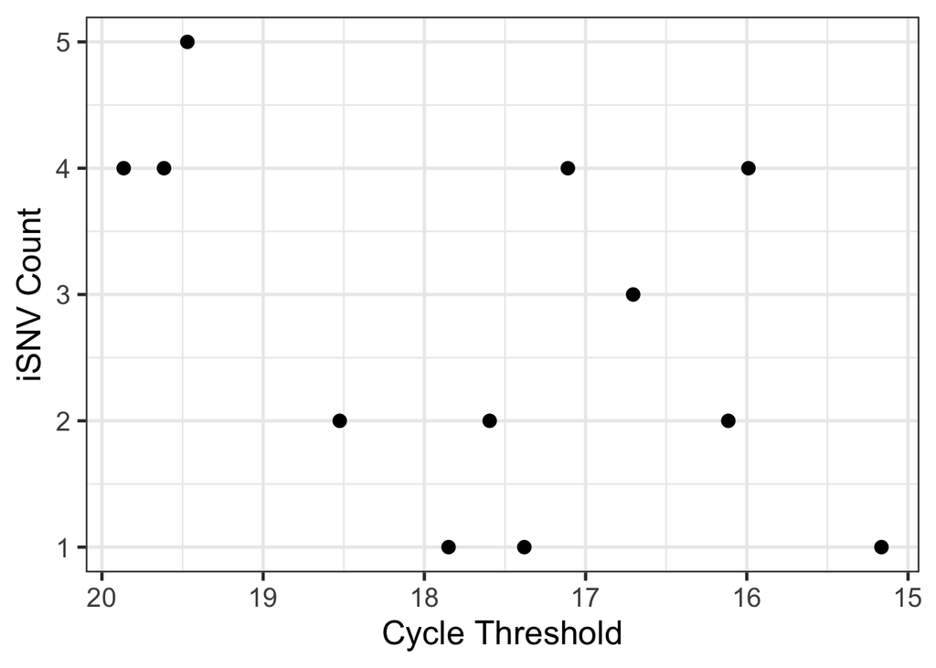

It’s clear that Ct value doesn’t correlate with the number of iSNVs called after filtering. This could have to do with (1) Ct value not being a close enough proxy for viral template number, (2) The number of iSNVs being too low to record any signal here, or (3) the Ct value being low enough across all these samples that RNA levels aren’t the limiting factor in our sensitivity to call variants.

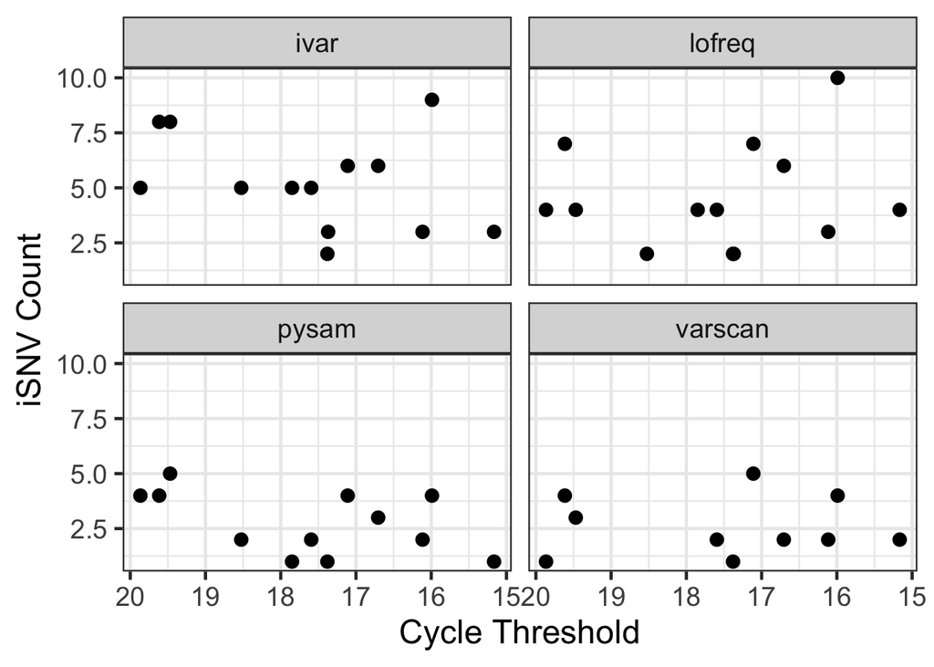

Although the number of “passing” variants is a little bit different between the callers, the relationship between iSNVs and Ct holds in all three methods.

## Average Number of iSNVs

I wanted to see how many intrahost variants there are on average across samples. Just like above, these needed to pass quality controls.

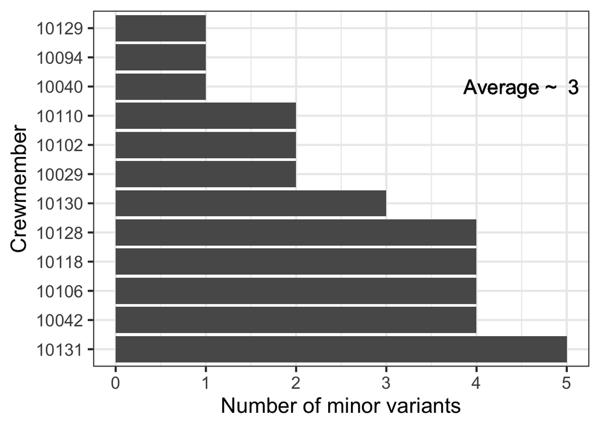

There is a mean of ~ 3 minor variants per sample.

## Average Variant Frequency

Next, I wanted to look at the average frequency of these intrahost variants, as well as their distributioon across the creq members.

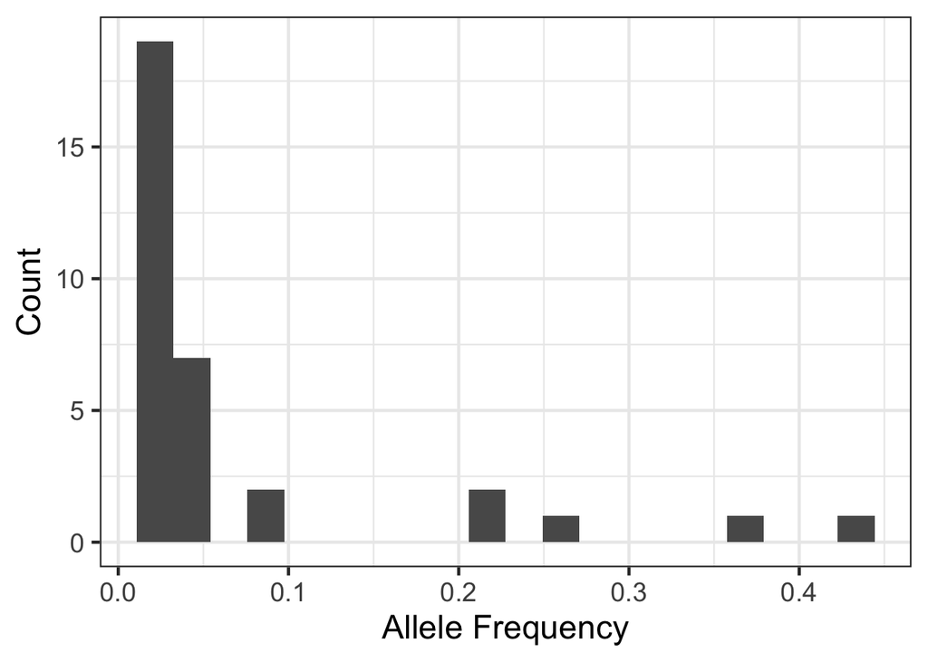

The vast majority of intrahost variants are present at less than 10% frequency. However, there are some present at quite high frequency, even approaching 50%. These are particularly interesting if they appear elsewhere in the phylogeny of the boat samples or washington state.

## Variant Position

This next plot shows the positions of each variant in the genome, colored by what the mutational effect is, and labeled with the sample that it belongs to. Not a particularly useful plot, but most papers of intrahost mutations have some version of these. At least you can see that variants at low frequency are much more likely to be shared than those at high frequency. This discepecny will be adressed more specifically in `shared-variants-analysis.Rmd`.

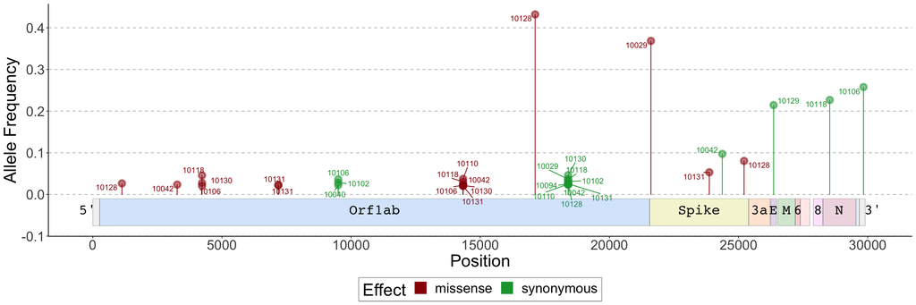